# NewYorkTimes

Maliat Islam

4/10/2021

## Creation of API KEY:

### For this assignment firstly, I have visited https://developer.nytimes.com/ website to create an accoun with NYT devlopers website.I have also registered an app named Ranalysis to get my API key.After acquiring the key,I have used it too look for the news article on the new COVID 19 variants.I have worked with Mike Kearney’s nytimes package to get access to the Article Search API. jsonlite is also implemented to read in the json data and transform into in a R dataframe.

```r
library(jsonlite)
library(tidyverse)
```

```r
library(ggplot2)
library(dplyr)
library(kableExtra)
devtools::install_github("mkearney/nytimes")
```

## Extracting Data:

### Term, begin date , end date parameters were created to access data.The date is formatted in YYYYMMDD. Term refers to the COVID variant news artcle.

```r
term <- "COVID variant" # Need to use + to string together separate words
begin_date <- str_replace_all(Sys.Date()-7, "-", "")
end_date <- str_replace_all(Sys.Date(), "-", "")
```

### A value named baseurl is created. after that the query was pasted with parameters and my API key to fetch articles regarding new COVID 19 variant.

```r
baseurl <- paste0("http://api.nytimes.com/svc/search/v2/articlesearch.json?q=",term,
                  "&begin_date=",begin_date,"&end_date=",end_date,
                  "&facet_filter=true&api-key=GOnSpbnTPil1XnvQ7BolKxAhE2LVH4bQ",sep="")
```

```r
initialQuery <- fromJSON(baseurl)
maxPages <- round((initialQuery$response$meta$hits[1] / 10)-1)
```

### A for loop is set to to loop through 0 to maximum pages. The maximum page has been set to 2.For each page a data frame is created by querying the baseurl and pasting on the page number.

```r
pages <- list()
for(i in 0:2){
  nytSearch <- fromJSON(paste0(baseurl, "&page=", i), flatten = TRUE) %>% data.frame()
  message("Retrieving page ", i)
  pages[[i+1]] <- nytSearch
  Sys.sleep(1)
}
```

```
## Retrieving page 0
```

```
## Retrieving page 1
```

```
## Retrieving page 2
```

## Transformatin to R data frame:

### After retrieving pages, all of them are combined into one dataframe.

```r
covidvariantdf <- rbind_pages(pages)
print(paste0("we have successfully scrapped ", dim(covidvariantdf)[1], " articles about new COVID variant"))
```

```
## [1] "we have successfully scrapped 30 articles about new COVID variant"
```

### Dataframe:

```r
view(covidvariantdf) %>% kable() %>%
  kable_styling(bootstrap_options = "striped", font_size = 10) %>%
  scroll_box(height = "500px", width = "100%")
```

| status | copyright | response.docs.abstract | response.docs.web_url | response.docs.snippet | response.docs.lead_paragraph | response.docs.source | response.docs.multimedia | response.docs.keywords | response.docs.pub_date | response.docs.document_type | response.docs.news_desk | response.docs.section_name | response.docs.type_of_material | response.docs._id | response.docs.word_count | response.docs.uri | response.docs.print_section | response.docs.print_page | response.docs.subsection_name | response.docs.headline.main | response.docs.headline.kicker | response.docs.headline.content_kicker | response.docs.headline.print_headline | response.docs.headline.name | response.docs.headline.seo | response.docs.headline.sub | response.docs.byline.original | response.docs.byline.person | response.docs.byline.organization | … |
| --- | --- | --- | --- | --- | --- | --- | --- | --- | --- | --- | --- | --- | --- | --- | --- | --- | --- | --- | --- | --- | --- | --- | --- | --- | --- | --- | --- | --- | --- | --- |
| OK | Copyright (c) 2021 The New York Times Company. All Rights Reserved. | The worrisome development comes as officials and scientists across the country warn of a fourth possible surge of the coronavirus. | https://www.nytimes.com/2021/04/07/us/covid-variant-infection.html | The worrisome development comes as officials and scientists across the country warn of a fourth possible surge of the coronavirus. | A highly infectious variant of the coronavirus that was first identified in Britain has now become the most common source of new infections in the United States, the director of the Centers for Diseas… | The New York Times | NULL | subject , subject , subject , subject , glocations , persons , organizations , internal-essential , Coronavirus (2019-nCoV) , Disease Rates , States (US) , United States , Walensky, Rochelle , Centers… | 2021-04-07T17:41:49+0000 | article | Washington | U.S. | News | nyt://article/769cf53d-5c1f-5d39-be13-9204e11d3f06 | 489 | nyt://article/769cf53d-5c1f-5d39-be13-9204e11d3f06 | NA | NA | NA | Most U.S. infections are now caused by a contagious virus variant, the C.D.C. says. | NA | NA | NA | NA | NA | NA | By Sheryl Gay Stolberg | Sheryl , Gay , Stolberg, NA , NA , reported, , 1 | NA | … |
| OK | Copyright (c) 2021 The New York Times Company. All Rights Reserved. | Vancouver has 25 confirmed cases of coronavirus within its organization and hasn’t played since late March. | https://www.nytimes.com/2021/04/07/sports/hockey/vancouver-canucks-coronavirus-outbreak.html | Vancouver has 25 confirmed cases of coronavirus within its organization and hasn’t played since late March. | VANCOUVER, British Columbia — A Covid-19 outbreak inside an N.H.L. team that began on March 30 has now impacted most of its players. | The New York Times | 0 , 0 , 0 , 0 , 0 , 0 , 0 , 0 , 0 , 0 , 0 , 0 , 0 , 0 , 0 , 0 , 0 , 0 , 0 , 0 , 0 , 0 , 0 , 0 , 0 , 0 , 0 , 0 , 0 , 0 , 0 , 0 , 0 , 0 , 0 , 0 , 0 , 0 , 0 , 0 , 0 , 0 , 0 , 0 , 0 , 0 , 0 , 0 , 0 , 0 , … | subject , organizations , subject , organizations , Hockey, Ice , National Hockey League, Coronavirus Reopenings, Vancouver Canucks , 1 , 2 , 3 , 4 , N , N , N , N | 2021-04-07T23:01:43+0000 | article | Sports | Sports | News | nyt://article/524e8549-9a5b-50a4-9dd1-a9c71747e58c | 530 | nyt://article/524e8549-9a5b-50a4-9dd1-a9c71747e58c | B | 11 | Hockey | Canucks’ Outbreak Can Be Traced to a Variant, Team Says | NA | NA | Outbreak Now Affects Most Players On Canucks | NA | NA | NA | By Gerald Narciso | Gerald , NA , Narciso , NA , NA , reported, , 1 | NA | … |
| OK | Copyright (c) 2021 The New York Times Company. All Rights Reserved. | Dr. Rochelle Walensky the director of The Centers for Disease Control and Prevention, said on Wednesday that the virus variant first discovered in Britain is now the most common source of new infectio… | https://www.nytimes.com/video/us/100000007697355/cdc-coronavirus-uk-variant.html | Dr. Rochelle Walensky the director of The Centers for Disease Control and Prevention, said on Wednesday that the virus variant first discovered in Britain is now the most common source of new infectio… | Dr. Rochelle Walensky the director of The Centers for Disease Control and Prevention, said on Wednesday that the virus variant first discovered in Britain is now the most common source of new infectio… | The New York Times | 0 , 0 , 0 , 0 , 0 , 0 , 0 , 0 , 0 , 0 , 0 , 0 , 0 , 0 , 0 , 0 , 0 , 0 , 0 , 0 , 0 , 0 , 0 , 0 , 0 , 0 , 0 , 0 , 0 , 0 , 0 , 0 , 0 , 0 , 0 , 0 , 0 , 0 , 0 , 0 , 0 , 0 , 0 , 0 , 0 , 0 , 0 , 0 , 0 , 0 , … | subject , subject , glocations , glocations , Disease Rates , Coronavirus (2019-nCoV), Great Britain , United States , 1 , 2 , 3 , 4 , N , N , N , N | 2021-04-07T20:38:38+0000 | multimedia |  | U.S. | Video | nyt://video/be57f392-058a-5384-8690-cdb2049913d1 | 0 | nyt://video/be57f392-058a-5384-8690-cdb2049913d1 | NA | NA | NA | C.D.C. Says U.K. Variant Is Now Most Common in the U.S. | NA | NA | NA | NA | NA | NA | By The Associated Press | NULL | The Associated Press | … |
| OK | Copyright (c) 2021 The New York Times Company. All Rights Reserved. | The B.1.1.7 variant, first identified in Britain, is now the source of most new coronavirus infections in the United States, the director of the Centers for Disease Control and Prevention said. | https://www.nytimes.com/2021/04/07/us/politics/coronavirus-variants-cdc.html | The B.1.1.7 variant, first identified in Britain, is now the source of most new coronavirus infections in the United States, the director of the Centers for Disease Control and Prevention said. | WASHINGTON — A highly infectious variant of the coronavirus that was first identified in Britain has become the most common source of new infections in the United States, the director of the Centers f… | The New York Times | 0 , 0 , 0 , 0 , 0 , 0 , 0 , 0 , 0 , 0 , 0 , 0 , 0 , 0 , 0 , 0 , 0 , 0 , 0 , 0 , 0 , 0 , 0 , 0 , 0 , 0 , 0 , 0 , 0 , 0 , 0 , 0 , 0 , 0 , 0 , 0 , 0 , 0 , 0 , 0 , 0 , 0 , 0 , 0 , 0 , 0 , 0 , 0 , 0 , 0 , … | subject , subject , subject , subject , organizations , persons , persons , subject , subject , Coronavirus (2019-nCoV) , Disease Rates , Deaths (Fatalities) , Vaccination and Immunization , Centers f… | 2021-04-07T22:19:22+0000 | article | Washington | U.S. | News | nyt://article/6e487dc2-f6f8-5f14-bf0f-29db5b1d5339 | 1029 | nyt://article/6e487dc2-f6f8-5f14-bf0f-29db5b1d5339 | A | 9 | Politics | More Contagious Virus Variant Is Now Dominant in U.S., C.D.C. Chief Says | NA | NA | Highly Contagious Variant Is Dominant in New Cases, Director of C.D.C. Warns | NA | NA | NA | By Sheryl Gay Stolberg and Carl Zimmer | Sheryl , Carl , Gay , NA , Stolberg, Zimmer , NA , NA , NA , NA , reported, reported, , , 1 , 2 | NA | … |
| OK | Copyright (c) 2021 The New York Times Company. All Rights Reserved. | Much of the continent is experiencing a wave of outbreaks driven by the B.1.1.7 variant, which ravaged Britain this winter. | https://www.nytimes.com/interactive/2021/04/09/world/europe/europe-coronavirus-variants.html | Much of the continent is experiencing a wave of outbreaks driven by the B.1.1.7 variant, which ravaged Britain this winter. | Much of the continent is experiencing a wave of outbreaks driven by the B.1.1.7 variant, which ravaged Britain this winter. | The New York Times | 0 , 0 , 0 , 0 , 0 , 0 , 0 , 0 , 0 , 0 , 0 , 0 , 0 , 0 , 0 , 0 , 0 , 0 , 0 , 0 , 0 , 0 , 0 , 0 , 0 , 0 , 0 , 0 , 0 , 0 , 0 , 0 , 0 , 0 , 0 , 0 , 0 , 0 , 0 , 0 , 0 , 0 , 0 , 0 , 0 , 0 , 0 , 0 , 0 , 0 , … | subject , subject , subject , glocations , Coronavirus (2019-nCoV) , Vaccination and Immunization, Disease Rates , Europe , 1 , 2 , 3 , 4 , N , N , N , N | 2021-04-09T04:30:01+0000 | multimedia | World | World | Interactive Feature | nyt://interactive/96982227-9c7c-533e-ada5-63fba8c10b9f | 0 | nyt://interactive/96982227-9c7c-533e-ada5-63fba8c10b9f | A | 8 | Europe | Rise of Variants in Europe Shows How Dangerous the Virus Can Be | NA | NA | Deadlier, More Contagious Variants Tearing Across Europe Show Virus Remains a Threat | NA | NA | NA | By Josh Holder, Allison McCann and Benjamin Mueller | Josh , Allison , Benjamin, NA , NA , NA , Holder , McCann , Mueller , NA , NA , NA , NA , NA , NA , reported, reported, reported, , , , 1 , 2 , 3 | NA | … |
| OK | Copyright (c) 2021 The New York Times Company. All Rights Reserved. | Test your knowledge of this week’s health news. | https://www.nytimes.com/interactive/2021/04/08/well/live/08healthquiz-04082021.html | Test your knowledge of this week’s health news. | Test your knowledge of this week’s health news. | The New York Times | 0 , 0 , 0 , 0 , 0 , 0 , 0 , 0 , 0 , 0 , 0 , 0 , 0 , 0 , 0 , 0 , 0 , 0 , 0 , 0 , 0 , 0 , 0 , 0 , 0 , 0 , 0 , 0 , 0 , 0 , 0 , 0 , 0 , 0 , 0 , 0 , 0 , 0 , 0 , 0 , 0 , 0 , 0 , 0 , 0 , 0 , 0 , 0 , 0 , 0 , … | subject , subject , subject , subject , subject , Medicine and Health , Vaccination and Immunization, Pain-Relieving Drugs , Coronavirus (2019-nCoV) , Exercise , 1 , 2 , 3 , 4 , 5 , N , N , N , N , N | 2021-04-08T09:00:06+0000 | multimedia | Well | Well | Interactive Feature | nyt://interactive/7d3f5954-a7fd-575e-9cc5-7bcc5120c994 | 0 | nyt://interactive/7d3f5954-a7fd-575e-9cc5-7bcc5120c994 | NA | NA | Live | Weekly Health Quiz: Vaccine Side Effects, Virus Variants and Predators on Treadmills | NA | NA | NA | NA | NA | NA | By Toby Bilanow | Toby , NA , Bilanow , NA , NA , reported, , 1 | NA | … |
| OK | Copyright (c) 2021 The New York Times Company. All Rights Reserved. | On Monday, Prime Minister Boris Johnson of Britain announced that lockdown restrictions would be eased in England to allow non-essential businesses to reopen following a period of lockdown due to a hi… | https://www.nytimes.com/video/us/politics/100000007692839/boris-johnson-virus-restrictions.html | On Monday, Prime Minister Boris Johnson of Britain announced that lockdown restrictions would be eased in England to allow non-essential businesses to reopen following a period of lockdown due to a hi… | On Monday, Prime Minister Boris Johnson of Britain announced that lockdown restrictions would be eased in England to allow non-essential businesses to reopen following a period of lockdown due to a hi… | AP | 0 , 0 , 0 , 0 , 0 , 0 , 0 , 0 , 0 , 0 , 0 , 0 , 0 , 0 , 0 , 0 , 0 , 0 , 0 , 0 , 0 , 0 , 0 , 0 , 0 , 0 , 0 , 0 , 0 , 0 , 0 , 0 , 0 , 0 , 0 , 0 , 0 , 0 , 0 , 0 , 0 , 0 , 0 , 0 , 0 , 0 , 0 , 0 , 0 , 0 , … | subject , subject , persons , glocations , Quarantines , Politics and Government, Johnson, Boris , Great Britain , 1 , 2 , 3 , 4 , N , N , N , N | 2021-04-05T20:35:40+0000 | multimedia |  | U.S. | Video | nyt://video/934fb08a-3748-53db-9a90-0c632e643718 | 0 | nyt://video/934fb08a-3748-53db-9a90-0c632e643718 | NA | NA | Politics | Boris Johnson Eases Covid-19 Restrictions | NA | NA | NA | NA | NA | NA | By The Associated Press | NULL | The Associated Press | … |
| OK | Copyright (c) 2021 The New York Times Company. All Rights Reserved. | Vaccinations have topped three million per day, but cases have risen again amid the presence of more-contagious variants, restriction rollbacks and more travel. | https://www.nytimes.com/interactive/2021/04/06/us/variants-cases-spread.html | Vaccinations have topped three million per day, but cases have risen again amid the presence of more-contagious variants, restriction rollbacks and more travel. | Vaccinations have topped three million per day, but cases have risen again amid the presence of more-contagious variants, restriction rollbacks and more travel. | The New York Times | 0 , 0 , 0 , 0 , 0 , 0 , 0 , 0 , 0 , 0 , 0 , 0 , 0 , 0 , 0 , 0 , 0 , 0 , 0 , 0 , 0 , 0 , 0 , 0 , 0 , 0 , 0 , 0 , 0 , 0 , 0 , 0 , 0 , 0 , 0 , 0 , 0 , 0 , 0 , 0 , 0 , 0 , 0 , 0 , 0 , 0 , 0 , 0 , 0 , 0 , … | subject , subject , subject , glocations , subject , subject , Coronavirus (2019-nCoV) , Coronavirus Risks and Safety Concerns, Disease Rates , United States , States (US) , Vaccination and Immunizati… | 2021-04-06T09:00:10+0000 | multimedia | U.S. | U.S. | Interactive Feature | nyt://interactive/f5e8fd31-0edd-5f40-8994-bfa42349beac | 0 | nyt://interactive/f5e8fd31-0edd-5f40-8994-bfa42349beac | A | 6 | NA | As Variants Have Spread, Progress Against the Virus in U.S. Has Stalled | NA | NA | States Reopen and People Start to Travel, but the Virus Changes, Too | NA | NA | NA | By Lauren Leatherby | Lauren , NA , Leatherby, NA , NA , reported , , 1 | NA | … |
| OK | Copyright (c) 2021 The New York Times Company. All Rights Reserved. | Here’s what you need to know about the week’s top stories. | https://www.nytimes.com/2021/04/04/briefing/virus-variants-capitol-hill-ncaa.html | Here’s what you need to know about the week’s top stories. | (Want to get this briefing by email? Here’s the sign-up.) | The New York Times | 0 , 0 , 0 , 0 , 0 , 0 , 0 , 0 , 0 , 0 , 0 , 0 , 0 , 0 , 0 , 0 , 0 , 0 , 0 , 0 , 0 , 0 , 0 , 0 , 0 , 0 , 0 , 0 , 0 , 0 , 0 , 0 , 0 , 0 , 0 , 0 , 0 , 0 , 0 , 0 , 0 , 0 , 0 , 0 , 0 , 0 , 0 , 0 , 0 , 0 , … | NULL | 2021-04-04T07:52:45+0000 | article | NYTNow | Briefing | briefing | nyt://article/089facfc-9fc0-5fee-9bbd-fc20edf507aa | 1274 | nyt://article/089facfc-9fc0-5fee-9bbd-fc20edf507aa | NA | NA | NA | Virus Variants, Capitol Hill, N.C.A.A.: Your Weekend Briefing | NA | NA | NA | NA | NA | NA | By Remy Tumin and Sarah Hughes | Remy , Sarah , NA , NA , Tumin , Hughes , NA , NA , NA , NA , reported, reported, , , 1 , 2 | NA | … |
| OK | Copyright (c) 2021 The New York Times Company. All Rights Reserved. | The new wave will hurt global efforts and vaccine supplies, experts say. Researchers are scrambling to assess whether new coronavirus variants are playing a role in India. | https://www.nytimes.com/2021/04/09/world/asia/india-covid-vaccine-variant.html | The new wave will hurt global efforts and vaccine supplies, experts say. Researchers are scrambling to assess whether new coronavirus variants are playing a role in India. | NEW DELHI — When the coronavirus first struck India last year, the country enforced one of the world’s strictest national lockdowns. The warning was clear: A fast spread in a population of 1.3 billion… | The New York Times | 0 , 0 , 0 , 0 , 0 , 0 , 0 , 0 , 0 , 0 , 0 , 0 , 0 , 0 , 0 , 0 , 0 , 0 , 0 , 0 , 0 , 0 , 0 , 0 , 0 , 0 , 0 , 0 , 0 , 0 , 0 , 0 , 0 , 0 , 0 , 0 , 0 , 0 , 0 , 0 , 0 , 0 , 0 , 0 , 0 , 0 , 0 , 0 , 0 , 0 , … | glocations , subject , subject , subject , subject , subject , persons , subject , subject , India , Coronavirus (2019-nCoV) , Disease Rates , Quarantines , Vaccination and Immunization , Deaths (Fata… | 2021-04-09T15:09:59+0000 | article | Foreign | World | News | nyt://article/991951c4-62e3-512f-b4a7-aa2d4bd84a0c | 1428 | nyt://article/991951c4-62e3-512f-b4a7-aa2d4bd84a0c | A | 1 | Asia Pacific | Complacency and Missteps Deepen a Covid-19 Crisis in India | NA | NA | Complacency Deepens a Virus Disaster in India | NA | NA | NA | By Mujib Mashal and Hari Kumar | Mujib , Hari , NA , NA , Mashal , Kumar , NA , NA , NA , NA , reported, reported, , , 1 , 2 | NA | … |
| OK | Copyright (c) 2021 The New York Times Company. All Rights Reserved. | Pediatricians should be vigilant, experts said, after the release of the largest U.S. study of the syndrome, MIS-C, that can strike young people weeks after their coronavirus infection. | https://www.nytimes.com/2021/04/06/health/covid-children-mis-c.html | Pediatricians should be vigilant, experts said, after the release of the largest U.S. study of the syndrome, MIS-C, that can strike young people weeks after their coronavirus infection. | Many children and teenagers who developed the mysterious inflammatory syndrome that can emerge several weeks after contracting the coronavirus never had classic Covid-19 symptoms at the time of their … | The New York Times | 0 , 0 , 0 , 0 , 0 , 0 , 0 , 0 , 0 , 0 , 0 , 0 , 0 , 0 , 0 , 0 , 0 , 0 , 0 , 0 , 0 , 0 , 0 , 0 , 0 , 0 , 0 , 0 , 0 , 0 , 0 , 0 , 0 , 0 , 0 , 0 , 0 , 0 , 0 , 0 , 0 , 0 , 0 , 0 , 0 , 0 , 0 , 0 , 0 , 0 , … | subject , subject , subject , subject , subject , subject , organizations , organizations , subject , subject , your-feed-science , Disease Rates , Coronavirus (2019-nCoV) , Research , Children and Ch… | 2021-04-06T15:33:41+0000 | article | Science | Health | News | nyt://article/698f3fdd-1ae4-5ab5-a3bb-1e361f6298b4 | 1300 | nyt://article/698f3fdd-1ae4-5ab5-a3bb-1e361f6298b4 | A | 4 | NA | Many Children With Serious Inflammatory Syndrome Had No Covid Symptoms | NA | NA | Mysterious Malady Hits Asymptomatic Young | NA | NA | NA | By Pam Belluck | Pam , NA , Belluck , NA , NA , reported, , 1 | NA | … |
| OK | Copyright (c) 2021 The New York Times Company. All Rights Reserved. | Quotation of the Day for Saturday, April 10, 2021. | https://www.nytimes.com/2021/04/09/todayspaper/quotation-of-the-day-to-speed-up-some-call-for-delaying-second-shots.html | Quotation of the Day for Saturday, April 10, 2021. | “Relying on one dose of Moderna or Pfizer to stop variants like B.1.351 is like using a BB gun to stop a charging rhino.” | The New York Times | NULL | NULL | 2021-04-10T02:42:09+0000 | article | Summary | Today’s Paper | Quote | nyt://article/6711a391-c819-546d-a1fb-3029c9637374 | 54 | nyt://article/6711a391-c819-546d-a1fb-3029c9637374 | A | 3 | NA | Quotation of the Day: To Speed Up, Some Call for Delaying Second Shots | NA | NA | Quote of the Day | NA | NA | NA | NA | NULL | NA | … |
| OK | Copyright (c) 2021 The New York Times Company. All Rights Reserved. | A year ago, their rehearsal was one of the first documented superspreader events. But tragedy and isolation couldn’t keep their voices apart. | https://www.nytimes.com/interactive/2021/04/08/magazine/skagit-valley-chorale-covid-superspreader.html | A year ago, their rehearsal was one of the first documented superspreader events. But tragedy and isolation couldn’t keep their voices apart. | A year ago, their rehearsal was one of the first documented superspreader events. But tragedy and isolation couldn’t keep their voices apart. | The New York Times | 0 , 0 , 0 , 0 , 0 , 0 , 0 , 0 , 0 , 0 , 0 , 0 , 0 , 0 , 0 , 0 , 0 , 0 , 0 , 0 , 0 , 0 , 0 , 0 , 0 , 0 , 0 , 0 , 0 , 0 , 0 , 0 , 0 , 0 , 0 , 0 , 0 , 0 , 0 , 0 , 0 , 0 , 0 , 0 , 0 , 0 , 0 , 0 , 0 , 0 , … | subject , glocations , subject , subject , subject , subject , organizations , organizations , subject , subject , Music , Skagit County (Wash) , Gospel Music , Coronavirus (2019-nCoV) , Coronavirus R… | 2021-04-08T08:22:43+0000 | multimedia | Magazine | Magazine | Interactive Feature | nyt://interactive/564eb8b1-42d2-5eba-8f03-b22a557396fc | 0 | nyt://interactive/564eb8b1-42d2-5eba-8f03-b22a557396fc | MM | 32 | NA | How the Skagit Valley Chorale Learned to Sing Again Amid Covid | NA | NA | Voices Carry | NA | NA | NA | By Kim Tingley | Kim , NA , Tingley , NA , NA , reported, , 1 | NA | … |
| OK | Copyright (c) 2021 The New York Times Company. All Rights Reserved. | Stretching the time between the first and second doses would greatly accelerate the rate at which people get at least partial protection. But some experts fear it could also lead to new variants. | https://www.nytimes.com/2021/04/09/health/covid-vaccine-second-dose-delay.html | Stretching the time between the first and second doses would greatly accelerate the rate at which people get at least partial protection. But some experts fear it could also lead to new variants. | The prospect of a fourth wave of the coronavirus, with new cases climbing sharply in the Upper Midwest, has reignited a debate among vaccine experts over how long to wait between the first and second … | The New York Times | 0 , 0 , 0 , 0 , 0 , 0 , 0 , 0 , 0 , 0 , 0 , 0 , 0 , 0 , 0 , 0 , 0 , 0 , 0 , 0 , 0 , 0 , 0 , 0 , 0 , 0 , 0 , 0 , 0 , 0 , 0 , 0 , 0 , 0 , 0 , 0 , 0 , 0 , 0 , 0 , 0 , 0 , 0 , 0 , 0 , 0 , 0 , 0 , 0 , 0 , … | subject , subject , glocations , subject , Vaccination and Immunization, Coronavirus (2019-nCoV) , United States , your-feed-healthcare , 1 , 2 , 3 , 4 , N , N , N , N | 2021-04-09T14:37:56+0000 | article | Science | Health | News | nyt://article/0c945aa9-e451-5aa4-ada9-589f8da3140a | 1416 | nyt://article/0c945aa9-e451-5aa4-ada9-589f8da3140a | A | 4 | NA | To Speed Vaccination, Some Call for Delaying Second Shots | Matter | NA | To Speed Up, Some Call for Delaying Second Shots | NA | NA | NA | By Carl Zimmer | Carl , NA , Zimmer , NA , NA , reported, , 1 | NA | … |
| OK | Copyright (c) 2021 The New York Times Company. All Rights Reserved. | When asked why his state wasn’t seeing higher reported cases after removing restrictions, the Texas governor speculated that the population had reached herd immunity. | https://www.nytimes.com/2021/04/11/world/texas-herd-immunity-governor.html | When asked why his state wasn’t seeing higher reported cases after removing restrictions, the Texas governor speculated that the population had reached herd immunity. | Gov. Greg Abbott of Texas may have been overly optimistic on Sunday when he said on Fox News that his state could be “very close” to herd immunity — the point where so much of the population is immune… | The New York Times | 0 , 0 , 0 , 0 , 0 , 0 , 0 , 0 , 0 , 0 , 0 , 0 , 0 , 0 , 0 , 0 , 0 , 0 , 0 , 0 , 0 , 0 , 0 , 0 , 0 , 0 , 0 , 0 , 0 , 0 , 0 , 0 , 0 , 0 , 0 , 0 , 0 , 0 , 0 , 0 , 0 , 0 , 0 , 0 , 0 , 0 , 0 , 0 , 0 , 0 , … | subject , glocations , subject , subject , subject , organizations , glocations , glocations , internal-essential , Texas , Coronavirus (2019-nCoV) , Vaccination and Immunization, States (US) , Republ… | 2021-04-11T17:49:53+0000 | article | Science | World | News | nyt://article/0765daa3-c7ca-5b67-8ce7-808a8c504d5e | 413 | nyt://article/0765daa3-c7ca-5b67-8ce7-808a8c504d5e | NA | NA | NA | Has Texas achieved herd immunity? “There is no way on God’s green earth,” an expert says. | NA | NA | NA | NA | NA | NA | By Denise Grady | Denise , NA , Grady , NA , NA , reported, , 1 | NA | … |
| OK | Copyright (c) 2021 The New York Times Company. All Rights Reserved. | At least 16 players and a coach are on the N.H.L.’s Covid-19 protocol list, and the team has postponed four games because of the virus. | https://www.nytimes.com/2021/04/05/sports/hockey/hockey-canucks-covid.html | At least 16 players and a coach are on the N.H.L.’s Covid-19 protocol list, and the team has postponed four games because of the virus. | VANCOUVER, British Columbia — The N.H.L.’s Covid-19 protocols have sidelined more than half of the Vancouver Canucks, as well as one member of the coaching staff, an extraordinary impact of the corona… | The New York Times | 0 , 0 , 0 , 0 , 0 , 0 , 0 , 0 , 0 , 0 , 0 , 0 , 0 , 0 , 0 , 0 , 0 , 0 , 0 , 0 , 0 , 0 , 0 , 0 , 0 , 0 , 0 , 0 , 0 , 0 , 0 , 0 , 0 , 0 , 0 , 0 , 0 , 0 , 0 , 0 , 0 , 0 , 0 , 0 , 0 , 0 , 0 , 0 , 0 , 0 , … | subject , subject , subject , organizations , organizations , persons , persons , persons , Hockey, Ice , Coronavirus (2019-nCoV) , Workplace Hazards and Violations, National Hockey League , Vancouver… | 2021-04-05T19:14:08+0000 | article | Sports | Sports | News | nyt://article/84132309-949e-5890-83af-0c3d97800eb6 | 853 | nyt://article/84132309-949e-5890-83af-0c3d97800eb6 | B | 10 | Hockey | Vancouver Canucks Brought to a Standstill by the Pandemic | NA | NA | Canucks Idle for a Second Week With 16 Players Sidelined by the Virus | NA | NA | NA | By Gerald Narciso | Gerald , NA , Narciso , NA , NA , reported, , 1 | NA | … |
| OK | Copyright (c) 2021 The New York Times Company. All Rights Reserved. | The spread of highly contagious coronavirus variants has dampened optimism about ending the pandemic even as vaccinations spread. | https://www.nytimes.com/2021/04/05/nyregion/coronavirus-vaccine-recipients.html | The spread of highly contagious coronavirus variants has dampened optimism about ending the pandemic even as vaccinations spread. | [Want to get New York Today by email? Here’s the sign-up.] | The New York Times | 0 , 0 , 0 , 0 , 0 , 0 , 0 , 0 , 0 , 0 , 0 , 0 , 0 , 0 , 0 , 0 , 0 , 0 , 0 , 0 , 0 , 0 , 0 , 0 , 0 , 0 , 0 , 0 , 0 , 0 , 0 , 0 , 0 , 0 , 0 , 0 , 0 , 0 , 0 , 0 , 0 , 0 , 0 , 0 , 0 , 0 , 0 , 0 , 0 , 0 , … | glocations , subject , subject , subject , subject , New York City , Theater , Coronavirus (2019-nCoV) , Vaccination and Immunization, Disease Rates , 1 , 2 , 3 , 4 , 5 , N , N , N , N , N | 2021-04-05T09:03:41+0000 | article | Metro | New York | briefing | nyt://article/a79bdf99-ffdc-558b-96ef-93273cf2a857 | 1016 | nyt://article/a79bdf99-ffdc-558b-96ef-93273cf2a857 | NA | NA | NA | One-Third of New Yorkers Have Received a Vaccine Shot | New York Today | NA | NA | NA | NA | NA | By Mihir Zaveri | Mihir , NA , Zaveri , NA , NA , reported, , 1 | NA | … |
| OK | Copyright (c) 2021 The New York Times Company. All Rights Reserved. | India has become the epicenter of the coronavirus outbreak. | https://www.nytimes.com/2021/04/09/us/coronavirus-today.html | India has become the epicenter of the coronavirus outbreak. | India has become the epicenter of the coronavirus outbreak, reporting a record of 131,968 new cases in the last 24 hours as the virus spins out of control. Deaths are rising, hospitals are quickly fil… | The New York Times | 0 , 0 , 0 , 0 , 0 , 0 , 0 , 0 , 0 , 0 , 0 , 0 , 0 , 0 , 0 , 0 , 0 , 0 , 0 , 0 , 0 , 0 , 0 , 0 , 0 , 0 , 0 , 0 , 0 , 0 , 0 , 0 , 0 , 0 , 0 , 0 , 0 , 0 , 0 , 0 , 0 , 0 , 0 , 0 , 0 , 0 , 0 , 0 , 0 , 0 , … | NULL | 2021-04-09T20:39:09+0000 | article | NYTNow | U.S. | News | nyt://article/4ed5163f-7bcf-58b1-b85f-4bdaec32ce69 | 1105 | nyt://article/4ed5163f-7bcf-58b1-b85f-4bdaec32ce69 | NA | NA | NA | Coronavirus Briefing: What Happened Today | NA | NA | NA | NA | NA | NA | By Jonathan Wolfe | Jonathan, NA , Wolfe , NA , NA , reported, , 1 | NA | … |
| OK | Copyright (c) 2021 The New York Times Company. All Rights Reserved. | The president pushed up his target date by two weeks, matching the timetable already being put in place by many states. | https://www.nytimes.com/2021/04/06/us/politics/biden-vaccine-all-adults-eligible.html | The president pushed up his target date by two weeks, matching the timetable already being put in place by many states. | WASHINGTON — President Biden on Tuesday moved up by two weeks, to April 19, his deadline for states to make every American adult eligible for coronavirus vaccination, following the lead of states arou… | The New York Times | 0 , 0 , 0 , 0 , 0 , 0 , 0 , 0 , 0 , 0 , 0 , 0 , 0 , 0 , 0 , 0 , 0 , 0 , 0 , 0 , 0 , 0 , 0 , 0 , 0 , 0 , 0 , 0 , 0 , 0 , 0 , 0 , 0 , 0 , 0 , 0 , 0 , 0 , 0 , 0 , 0 , 0 , 0 , 0 , 0 , 0 , 0 , 0 , 0 , 0 , … | persons , subject , subject , subject , subject , glocations , subject , subject , subject , Biden, Joseph R Jr , Coronavirus (2019-nCoV) , Vaccination and Immunization , Age, Chronological , Coronavi… | 2021-04-06T23:04:18+0000 | article | Washington | U.S. | News | nyt://article/332e5093-f418-5d39-b3a4-536c00dbe9f8 | 856 | nyt://article/332e5093-f418-5d39-b3a4-536c00dbe9f8 | A | 7 | Politics | Biden Moves Up Vaccine Eligibility Deadline for All Adults to April 19 | NA | NA | Biden Moves Up Deadline for Vaccine Eligibility | NA | NA | NA | By Sheryl Gay Stolberg | Sheryl , Gay , Stolberg, NA , NA , reported, , 1 | NA | … |
| OK | Copyright (c) 2021 The New York Times Company. All Rights Reserved. | Much of the continent remains closed to Americans because of the virus, but many travelers want to visit this summer. Will their plans materialize? | https://www.nytimes.com/2021/04/09/travel/vacation-summer-europe.html | Much of the continent remains closed to Americans because of the virus, but many travelers want to visit this summer. Will their plans materialize? | My husband and I are currently planning a trip to Ireland, Portugal and Italy for August and September. We are only reserving hotels with free cancellation policies and our airline tickets can be chan… | The New York Times | 0 , 0 , 0 , 0 , 0 , 0 , 0 , 0 , 0 , 0 , 0 , 0 , 0 , 0 , 0 , 0 , 0 , 0 , 0 , 0 , 0 , 0 , 0 , 0 , 0 , 0 , 0 , 0 , 0 , 0 , 0 , 0 , 0 , 0 , 0 , 0 , 0 , 0 , 0 , 0 , 0 , 0 , 0 , 0 , 0 , 0 , 0 , 0 , 0 , 0 , … | glocations , glocations , glocations , glocations , organizations , organizations , organizations , organizations , organizations , subject , subject , subject , subject , subject , Europe , Great Bri… | 2021-04-09T09:00:19+0000 | article | Travel | Travel | News | nyt://article/c8df05a1-6b24-55c5-8ad8-2d403b316cd9 | 1475 | nyt://article/c8df05a1-6b24-55c5-8ad8-2d403b316cd9 | NA | NA | NA | Help! I Want to Go to Europe in August. Is This a Pipe Dream? | Tripped Up | NA | NA | NA | NA | NA | By Sarah Firshein | Sarah , NA , Firshein, NA , NA , reported, , 1 | NA | … |
| OK | Copyright (c) 2021 The New York Times Company. All Rights Reserved. | Across white evangelical America, reasons not to get vaccinated have spread quickly. | https://www.nytimes.com/2021/04/05/world/millions-of-white-evangelicals-do-not-intend-to-get-vaccinated.html |  | Across white evangelical America, reasons not to get vaccinated have spread quickly. | The New York Times | 0 , 0 , 0 , 0 , 0 , 0 , 0 , 0 , 0 , 0 , 0 , 0 , 0 , 0 , 0 , 0 , 0 , 0 , 0 , 0 , 0 , 0 , 0 , 0 , 0 , 0 , 0 , 0 , 0 , 0 , 0 , 0 , 0 , 0 , 0 , 0 , 0 , 0 , 0 , 0 , 0 , 0 , 0 , 0 , 0 , 0 , 0 , 0 , 0 , 0 , … | subject , internal-essential, 1 , N | 2021-04-05T09:37:31+0000 | article | Foreign | World | News | nyt://article/74470404-c1b0-5170-bdb3-2f7df7509ccd | 515 | nyt://article/74470404-c1b0-5170-bdb3-2f7df7509ccd | NA | NA | NA | Millions of white evangelicals do not intend to get vaccinated. | NA | NA | NA | NA | NA | NA | By Elizabeth Dias and Ruth Graham | Elizabeth, Ruth , NA , NA , Dias , Graham , NA , NA , NA , NA , reported , reported , , , 1 , 2 | NA | … |
| OK | Copyright (c) 2021 The New York Times Company. All Rights Reserved. | High-profile arrests rock Jordan. | https://www.nytimes.com/2021/04/04/briefing/jordan-taliban-negotiations.html | High-profile arrests rock Jordan. | The Jordanian government has arrested high-profile figures, including Sharif Hassan bin Zaid, a member of the royal family, and Bassem Awadallah, a former chief of the royal court, an unusual developm… | The New York Times | 0 , 0 , 0 , 0 , 0 , 0 , 0 , 0 , 0 , 0 , 0 , 0 , 0 , 0 , 0 , 0 , 0 , 0 , 0 , 0 , 0 , 0 , 0 , 0 , 0 , 0 , 0 , 0 , 0 , 0 , 0 , 0 , 0 , 0 , 0 , 0 , 0 , 0 , 0 , 0 , 0 , 0 , 0 , 0 , 0 , 0 , 0 , 0 , 0 , 0 , … | glocations , glocations , glocations , persons , subject , subject , subject , subject , subject , subject , subject , subject , AFGHANISTAN , Jordan , United States , Hamzah bin Hussein, Prince of Jo… | 2021-04-04T21:21:30+0000 | article | NYTNow | Briefing | News | nyt://article/0e4e5b0f-5358-53d5-b3b3-cd28447edfba | 1201 | nyt://article/0e4e5b0f-5358-53d5-b3b3-cd28447edfba | NA | NA | NA | Your Monday Briefing | NA | NA | NA | NA | NA | NA | By Amelia Nierenberg | Amelia , NA , Nierenberg, NA , NA , reported , , 1 | NA | … |
| OK | Copyright (c) 2021 The New York Times Company. All Rights Reserved. | Vaccine passports are shaping up to be the next big wedge issue in the United States. | https://www.nytimes.com/2021/04/06/us/coronavirus-today-vaccines.html | Vaccine passports are shaping up to be the next big wedge issue in the United States. | As the ranks of the inoculated in the U.S. grow, businesses, schools and politicians are considering “vaccine passports” — digital proof of vaccination against the coronavirus — as a path to reviving … | The New York Times | 0 , 0 , 0 , 0 , 0 , 0 , 0 , 0 , 0 , 0 , 0 , 0 , 0 , 0 , 0 , 0 , 0 , 0 , 0 , 0 , 0 , 0 , 0 , 0 , 0 , 0 , 0 , 0 , 0 , 0 , 0 , 0 , 0 , 0 , 0 , 0 , 0 , 0 , 0 , 0 , 0 , 0 , 0 , 0 , 0 , 0 , 0 , 0 , 0 , 0 , … | NULL | 2021-04-06T21:17:46+0000 | article | NYTNow | U.S. | News | nyt://article/0d3b458c-60f7-527d-a279-896fe7681ec3 | 1272 | nyt://article/0d3b458c-60f7-527d-a279-896fe7681ec3 | NA | NA | NA | Coronavirus Briefing: What Happened Today | NA | NA | NA | NA | NA | NA | By Jonathan Wolfe | Jonathan, NA , Wolfe , NA , NA , reported, , 1 | NA | … |
| OK | Copyright (c) 2021 The New York Times Company. All Rights Reserved. | Gov. Gretchen Whitmer, a Democrat, said she had pushed the president unsuccessfully to send more vaccines to her state, where hospitals are filling. | https://www.nytimes.com/2021/04/09/us/michigan-covid-vaccine.html | Gov. Gretchen Whitmer, a Democrat, said she had pushed the president unsuccessfully to send more vaccines to her state, where hospitals are filling. | Gov. Gretchen Whitmer of Michigan said Friday that she had urged President Biden to surge Covid-19 vaccines into her state, where a worst-in-the-nation outbreak has filled hospitals and forced some sc… | The New York Times | 0 , 0 , 0 , 0 , 0 , 0 , 0 , 0 , 0 , 0 , 0 , 0 , 0 , 0 , 0 , 0 , 0 , 0 , 0 , 0 , 0 , 0 , 0 , 0 , 0 , 0 , 0 , 0 , 0 , 0 , 0 , 0 , 0 , 0 , 0 , 0 , 0 , 0 , 0 , 0 , 0 , 0 , 0 , 0 , 0 , 0 , 0 , 0 , 0 , 0 , … | subject , subject , subject , persons , persons , glocations , internal-essential , Coronavirus (2019-nCoV) , Vaccination and Immunization, Whitmer, Gretchen , Biden, Joseph R Jr , Michigan , 1 , 2 , … | 2021-04-09T16:10:47+0000 | article | National | U.S. | News | nyt://article/13a9bd8b-c46e-5018-b092-204d316e6857 | 838 | nyt://article/13a9bd8b-c46e-5018-b092-204d316e6857 | NA | NA | NA | Michigan’s governor, confronting a surge in virus cases, calls on Biden for more vaccines. | NA | NA | NA | NA | NA | NA | By Mitch Smith and Julie Bosman | Mitch , Julie , NA , NA , Smith , Bosman , NA , NA , NA , NA , reported, reported, , , 1 , 2 | NA | … |
| OK | Copyright (c) 2021 The New York Times Company. All Rights Reserved. | And now? Four million is the new benchmark for the U.S. | https://www.nytimes.com/2021/04/06/briefing/three-million-daily-shots-achieved.html | And now? Four million is the new benchmark for the U.S. | Shortly after President Biden took office, I began asking his aides why their publicly announced goal for Covid-19 vaccine distribution — an average of one million shots a day — was so unambitious. Th… | The New York Times | 0 , 0 , 0 , 0 , 0 , 0 , 0 , 0 , 0 , 0 , 0 , 0 , 0 , 0 , 0 , 0 , 0 , 0 , 0 , 0 , 0 , 0 , 0 , 0 , 0 , 0 , 0 , 0 , 0 , 0 , 0 , 0 , 0 , 0 , 0 , 0 , 0 , 0 , 0 , 0 , 0 , 0 , 0 , 0 , 0 , 0 , 0 , 0 , 0 , 0 , … | NULL | 2021-04-06T10:38:19+0000 | article | NYTNow | Briefing | briefing | nyt://article/52e89e18-0d7d-53ef-8e6b-330344ba3280 | 1503 | nyt://article/52e89e18-0d7d-53ef-8e6b-330344ba3280 | NA | NA | NA | Three Million Daily Shots, Achieved | The Morning Newsletter | NA | NA | NA | NA | NA | By David Leonhardt | David , NA , Leonhardt, NA , NA , reported , , 1 | NA | … |
| OK | Copyright (c) 2021 The New York Times Company. All Rights Reserved. | Israel’s vaccination program has been remarkably swift and successful. In recent weeks, new coronavirus infections have dropped significantly, from a peak of 10,000 a day in January to a few hundred b… | https://www.nytimes.com/2021/04/05/world/israel-offers-a-hint-of-what-post-pandemic-life-may-look-like.html |  | Israel’s vaccination program has been remarkably swift and successful. In recent weeks, new coronavirus infections have dropped significantly, from a peak of 10,000 a day in January to a few hundred b… | The New York Times | 0 , 0 , 0 , 0 , 0 , 0 , 0 , 0 , 0 , 0 , 0 , 0 , 0 , 0 , 0 , 0 , 0 , 0 , 0 , 0 , 0 , 0 , 0 , 0 , 0 , 0 , 0 , 0 , 0 , 0 , 0 , 0 , 0 , 0 , 0 , 0 , 0 , 0 , 0 , 0 , 0 , 0 , 0 , 0 , 0 , 0 , 0 , 0 , 0 , 0 , … | subject , internal-essential, 1 , N | 2021-04-05T08:53:51+0000 | article | Foreign | World | News | nyt://article/4495fd2d-103e-5fcc-9dea-406a7994cf05 | 429 | nyt://article/4495fd2d-103e-5fcc-9dea-406a7994cf05 | NA | NA | NA | Israel offers a hint of what post-pandemic life may look like. | NA | NA | NA | NA | NA | NA | By Isabel Kershner | Isabel , NA , Kershner, NA , NA , reported, , 1 | NA | … |
| OK | Copyright (c) 2021 The New York Times Company. All Rights Reserved. | The global economy is expected to expand by 6 percent this year, up from a previous projection of 5.5 percent, after a contraction of 3.3 percent in 2020. | https://www.nytimes.com/2021/04/06/business/imf-outlook-global-economy.html | The global economy is expected to expand by 6 percent this year, up from a previous projection of 5.5 percent, after a contraction of 3.3 percent in 2020. | The global economy is recovering from the coronavirus pandemic faster than previously expected, largely thanks to the strength of the United States, but the International Monetary Fund warned on Tuesd… | The New York Times | 0 , 0 , 0 , 0 , 0 , 0 , 0 , 0 , 0 , 0 , 0 , 0 , 0 , 0 , 0 , 0 , 0 , 0 , 0 , 0 , 0 , 0 , 0 , 0 , 0 , 0 , 0 , 0 , 0 , 0 , 0 , 0 , 0 , 0 , 0 , 0 , 0 , 0 , 0 , 0 , 0 , 0 , 0 , 0 , 0 , 0 , 0 , 0 , 0 , 0 , … | subject , subject , subject , subject , organizations , International Trade and World Market, Coronavirus (2019-nCoV) , Economic Conditions and Trends , Vaccination and Immunization , International Mo… | 2021-04-06T12:30:05+0000 | article | Business | Business Day | News | nyt://article/1112a6ea-a241-5ca5-a2d9-419b2169c2c0 | 436 | nyt://article/1112a6ea-a241-5ca5-a2d9-419b2169c2c0 | NA | NA | NA | The I.M.F. sees a faster economic recovery as vaccines are deployed. | NA | NA | NA | NA | NA | NA | By Alan Rappeport | Alan , NA , Rappeport, NA , NA , reported , , 1 | NA | … |
| OK | Copyright (c) 2021 The New York Times Company. All Rights Reserved. | Millions of white evangelical adults in the U.S. do not intend to get vaccinated against Covid-19. Tenets of faith and mistrust of science play a role; so does politics. | https://www.nytimes.com/2021/04/05/us/covid-vaccine-evangelicals.html | Millions of white evangelical adults in the U.S. do not intend to get vaccinated against Covid-19. Tenets of faith and mistrust of science play a role; so does politics. | Stephanie Nana, an evangelical Christian in Edmond, Okla., refused to get a Covid-19 vaccine because she believed it contained “aborted cell tissue.” | The New York Times | 0 , 0 , 0 , 0 , 0 , 0 , 0 , 0 , 0 , 0 , 0 , 0 , 0 , 0 , 0 , 0 , 0 , 0 , 0 , 0 , 0 , 0 , 0 , 0 , 0 , 0 , 0 , 0 , 0 , 0 , 0 , 0 , 0 , 0 , 0 , 0 , 0 , 0 , 0 , 0 , 0 , 0 , 0 , 0 , 0 , 0 , 0 , 0 , 0 , 0 , … | subject , subject , subject , subject , glocations , subject , subject , Vaccination and Immunization, Evangelical Movement , Coronavirus (2019-nCoV) , Whites , United States , Fetal Tissue , Rumors a… | 2021-04-05T07:00:09+0000 | article | National | U.S. | News | nyt://article/6dda16bd-770f-51af-9f2b-fc3dae53743f | 1754 | nyt://article/6dda16bd-770f-51af-9f2b-fc3dae53743f | A | 1 | NA | White Evangelical Resistance Is Obstacle in Vaccination Effort | NA | NA | White Evangelical Resistance Is Obstacle in Vaccination Effort | NA | NA | NA | By Elizabeth Dias and Ruth Graham | Elizabeth, Ruth , NA , NA , Dias , Graham , NA , NA , NA , NA , reported , reported , , , 1 , 2 | NA | … |
| OK | Copyright (c) 2021 The New York Times Company. All Rights Reserved. | The extraordinary move came just days after officials learned the plant had ruined 15 million doses of Johnson & Johnson’s coronavirus vaccine. | https://www.nytimes.com/2021/04/03/us/politics/emergent-vaccine-plant-johnson-johnson.html | The extraordinary move came just days after officials learned the plant had ruined 15 million doses of Johnson & Johnson’s coronavirus vaccine. | WASHINGTON — The Biden administration on Saturday put Johnson & Johnson in charge of a troubled Baltimore manufacturing plant that ruined 15 million doses of the Johnson & Johnson coronavirus vaccine … | The New York Times | 0 , 0 , 0 , 0 , 0 , 0 , 0 , 0 , 0 , 0 , 0 , 0 , 0 , 0 , 0 , 0 , 0 , 0 , 0 , 0 , 0 , 0 , 0 , 0 , 0 , 0 , 0 , 0 , 0 , 0 , 0 , 0 , 0 , 0 , 0 , 0 , 0 , 0 , 0 , 0 , 0 , 0 , 0 , 0 , 0 , 0 , 0 , 0 , 0 , 0 , … | subject , subject , subject , subject , organizations , organizations , organizations , organizations , organizations , glocations , persons , Vaccination and Immunization , Public-Private Sector Coop… | 2021-04-04T01:30:36+0000 | article | Washington | U.S. | News | nyt://article/84a0a26e-53c9-5662-9465-acc0e37502a1 | 806 | nyt://article/84a0a26e-53c9-5662-9465-acc0e37502a1 | A | 7 | Politics | U.S. Taps Johnson & Johnson to Run Troubled Vaccine Plant | NA | NA | U.S. Replaces Plant Leaders After Mix-Up Ruins Doses | NA | NA | NA | By Sheryl Gay Stolberg | Sheryl , Gay , Stolberg, NA , NA , reported, , 1 | NA | … |
| OK | Copyright (c) 2021 The New York Times Company. All Rights Reserved. | We were spread across three continents, at the mercy of vaccine geopolitics. Which of us would be inoculated last? | https://www.nytimes.com/2021/04/11/health/coronavirus-vaccines-global-journey.html | We were spread across three continents, at the mercy of vaccine geopolitics. Which of us would be inoculated last? | In early February, my sister posted a video in our family’s WhatsApp group. | The New York Times | 0 , 0 , 0 , 0 , 0 , 0 , 0 , 0 , 0 , 0 , 0 , 0 , 0 , 0 , 0 , 0 , 0 , 0 , 0 , 0 , 0 , 0 , 0 , 0 , 0 , 0 , 0 , 0 , 0 , 0 , 0 , 0 , 0 , 0 , 0 , 0 , 0 , 0 , 0 , 0 , 0 , 0 , 0 , 0 , 0 , 0 , 0 , 0 , 0 , 0 , … | subject , subject , subject , subject , subject , subject , subject , subject , organizations , organizations , organizations , organizations , glocations , glocations , glocations , subject , Shortag… | 2021-04-11T07:00:10+0000 | article | SundayBusiness | Health | News | nyt://article/951f49de-d80f-564a-883e-8942a4dd643b | 2305 | nyt://article/951f49de-d80f-564a-883e-8942a4dd643b | BU | 1 | NA | My Family’s Global Vaccine Journey | NA | NA | One Family’s Global Quest for Vaccination | NA | NA | NA | By Pui-Wing Tam | Pui-wing, NA , Tam , NA , NA , reported, , 1 | NA | … |

### Barplot:

### The barplot refelects new COVID variants are mostly discussed in news articles.

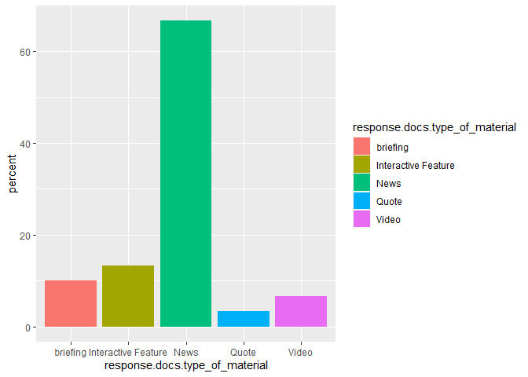

```r
covidvariantdf%>%
  group_by(response.docs.type_of_material) %>%
  summarize(count=n()) %>%
  mutate(percent = (count / sum(count))*100) %>%
  ggplot() +
  geom_bar(aes(y=percent, x=response.docs.type_of_material, fill=response.docs.type_of_material), stat = "identity")
```